# HW6 Unsupervised Learning HealthCare

Elijah Hall

July 15, 2018

## Unsupervised Learning

This assignment covers two common techniques in unsupervised learning, DSCAN and Hidden Markov Model (HMM). Will be used to explore data that has been adjusted for identifing anomolies.

```r
library(rmarkdown)
library(tidyverse)
library(data.table)
library(zipcode)
#library(scales)
library(plotly)
library(kableExtra)
library(dbscan)
library(fpc)
#library(stats)
library(ggdendro)
library(GGally)
library(pca3d)
library(factoextra)
#library(rattle.data)
library(gridExtra)
library(depmixS4)
library(tidyverse)
#suppressPackageStartupMessages(library(tidyverse))
library(dplyr)
```

```r
abb2state <- function(name, convert = F, strict = F){
  data(state)
  # state data doesn't include DC
  state = list()
  state[['name']] = c(state.name,"District Of Columbia")
  state[['abb']] = c(state.abb,"DC")

  if(convert) state[c(1,2)] = state[c(2,1)]

  single.a2s <- function(s){
    if(strict){
      is.in = tolower(state[['abb']]) %in% tolower(s)
      ifelse(any(is.in), state[['name']][is.in], NA)
    }else{
      # To check if input is in state full name or abb
      is.in = rapply(state, function(x) tolower(x) %in% tolower(s), how="list")
      state[['name']][is.in[[ifelse(any(is.in[['name']]), 'name', 'abb')]]]
    }
  }
  sapply(name, single.a2s)
} # https://gist.github.com/ligyxy/acc1410041fe2938a2f5

mytheme <- theme_bw()+
  theme(panel.border = element_blank(),
        axis.line = element_line(color = 'black'),
        plot.background = element_blank(),
        panel.grid.major = element_blank(),
        panel.grid.minor = element_blank(),
        plot.title = element_text(hjust = 0.5),
        axis.title.x = element_text(color="black", size=10),
        axis.title.y = element_text(color="black", size=10)
        )

#define additional parameters for plotly graphs
g <- list(
  scope = 'usa',
  projection = list(type = 'albers usa'),
  showland = TRUE,
  landcolor = toRGB("gray85"),
  subunitwidth = 1,
  countrywidth = 1,
  subunitcolor = toRGB("white"),
  countrycolor = toRGB("white")
)

m <- list(
  l = 50,
  r = 50,
  b = 100,
  t = 100,
  pad = 4
)
```

```r
#load in data
payment<- fread("Inpatient_Payment_System.csv")

#fix names
names(payment)<- str_replace_all(names(payment),pattern = " ", replacement = ".")
payment<- as.data.frame(payment)
idx<- as.numeric(which(unlist(map(payment[1,], is.numeric)))) #2 and 7 are id variables

kable(summary(payment[,9:12]))
```

|  | Total.Discharges | Average.Covered.Charges | Average.Total.Payments | Average.Medicare.Payments |
| --- | --- | --- | --- | --- |
|  | Min. : 11.00 | Min. : 1715 | Min. : 2420 | Min. : 659.3 |
|  | 1st Qu.: 15.00 | 1st Qu.: 21735 | 1st Qu.: 6261 | 1st Qu.: 4982.4 |
|  | Median : 22.00 | Median : 36050 | Median : 9185 | Median : 7680.9 |
|  | Mean : 36.82 | Mean : 55009 | Mean : 13220 | Mean : 11213.9 |
|  | 3rd Qu.: 39.00 | 3rd Qu.: 63474 | 3rd Qu.: 14655 | 3rd Qu.: 12442.5 |
|  | Max. :3990.00 | Max. :2794184 | Max. :449486 | Max. :417977.3 |

```r
kable(head(payment))
```

| DRG.Definition | Provider.Id | Provider.Name | Provider.Street.Address | Provider.City | Provider.State | Provider.Zip.Code | Hospital.Referral.Region.(HRR).Description | Total.Discharges | Average.Covered.Charges | Average.Total.Payments | Average.Medicare.Payments |
| --- | --- | --- | --- | --- | --- | --- | --- | --- | --- | --- | --- |
| 001 - HEART TRANSPLANT OR IMPLANT OF HEART ASSIST SYSTEM W MCC | 10033 | UNIVERSITY OF ALABAMA HOSPITAL | 619 SOUTH 19TH STREET | BIRMINGHAM | AL | 35233 | AL - Birmingham | 11 | 1014783.4 | 171081.2 | 141193.9 |
| 001 - HEART TRANSPLANT OR IMPLANT OF HEART ASSIST SYSTEM W MCC | 30103 | MAYO CLINIC HOSPITAL | 5777 EAST MAYO BOULEVARD | PHOENIX | AZ | 85054 | AZ - Phoenix | 28 | 382051.0 | 194081.4 | 167512.0 |
| 001 - HEART TRANSPLANT OR IMPLANT OF HEART ASSIST SYSTEM W MCC | 50025 | UNIVERSITY OF CALIFORNIA SAN DIEGO MEDICAL CENTER | 200 WEST ARBOR DRIVE | SAN DIEGO | CA | 92103 | CA - San Diego | 21 | 971881.5 | 324050.7 | 294419.6 |
| 001 - HEART TRANSPLANT OR IMPLANT OF HEART ASSIST SYSTEM W MCC | 50100 | SHARP MEMORIAL HOSPITAL | 7901 FROST ST | SAN DIEGO | CA | 92123 | CA - San Diego | 18 | 1517857.6 | 257177.3 | 233532.8 |
| 001 - HEART TRANSPLANT OR IMPLANT OF HEART ASSIST SYSTEM W MCC | 50108 | SUTTER MEDICAL CENTER, SACRAMENTO | 2825 CAPITOL AVENUE | SACRAMENTO | CA | 95816 | CA - Sacramento | 17 | 1470341.1 | 346150.1 | 338472.0 |
| 001 - HEART TRANSPLANT OR IMPLANT OF HEART ASSIST SYSTEM W MCC | 50262 | RONALD REAGAN U C L A MEDICAL CENTER | 757 WESTWOOD PLAZA | LOS ANGELES | CA | 90095 | CA - Los Angeles | 19 | 1450590.6 | 449486.1 | 404408.7 |

## Feature Engineering

The engineered features are ratios of the given variables by provider to their state.

```r
#create category for  Northeast,  Midwest, South, and West
Northeast<- c("Connecticut", "Maine", "Massachusetts", "New Hampshire", "Rhode Island", "Vermont", "New Jersey", "New York", "Pennsylvania")
names(Northeast)<- rep("Northeast", length(Northeast))

Midwest <- c("Illinois", "Indiana", "Michigan", "Ohio",  "Wisconsin", "Iowa", "Kansas", "Minnesota", 'Missouri', 'Nebraska', 'North Dakota', 'South Dakota')
names(Midwest)<- rep("Midwest", length(Midwest))

South<- c("Delaware", "Florida", "Georgia", "Maryland", "North Carolina", 'South Carolina', 'Virginia', 'District of Columbia',  'West Virginia', 'Alabama', 'Kentucky', 'Mississippi',  'Tennessee', 'Arkansas', 'Louisiana', 'Oklahoma', 'Texas')
names(South)<- rep("South", length(South))

West<- c('Arizona', 'Colorado', 'Idaho', 'Montana', 'Nevada', 'New Mexico', 'Utah',  'Wyoming', 'Alaska', 'California', 'Hawaii', 'Oregon',  'Washington')
names(West)<- rep("West", length(West))

#create df to hold all values for regions
region_df<- data.frame( sort(c(Northeast,Midwest, South, West)), names(sort(c(Northeast,Midwest, South, West))))
names(region_df)<- c("State", "Region")

#create abbreviations to match on
region_df$Provider.State <- abb2state(region_df$State,convert=T)

#create vector of regions to cbind
region<- c("character", length= nrow(payment))
for (i in 1:nrow(region_df)){

idx<-which(payment$Provider.State == region_df$Provider.State[i])
region[idx]<-as.character(region_df$Region[i])

}

payment<- cbind(payment,region)
remove(region_df)
```

```r
#ratio of DRG total payments to all payments
Region_total <- payment %>% group_by(region) %>%
       summarise( totals= sum(Total.Discharges*Average.Total.Payments))

payment2<- payment %>%
       left_join(Region_total, by=c("region")) %>%
       mutate( ratio_region_DRG_total_payments=(Total.Discharges*Average.Total.Payments)/totals) %>%
  dplyr::select(-totals)

remove(Region_total)

DRG_Region_avg <- payment2 %>% group_by(DRG.Definition, region) %>%
       summarise( mean_ratio_covered_total = mean(Average.Covered.Charges/Average.Total.Payments),
                  mean_ratio_medicare_total= mean(Average.Medicare.Payments/Average.Total.Payments),
                  mean_total_discharges          = mean(Total.Discharges),
                  mean_average_covered_charges   = mean(Average.Covered.Charges),
                  mean_average_total_payments    = mean(Average.Total.Payments),
                  mean_average_medicare_payments = mean(Average.Medicare.Payments),
                  mean_total_payment             = mean_average_total_payments*
                                                          mean_total_discharges
                )

# Append the average statistics back to the data to derive the ratios.
per_provider_reg <- payment2 %>%
       left_join(DRG_Region_avg, by=c("DRG.Definition","region")) %>%
       mutate( reg_ratio_covered_total =(Average.Covered.Charges/Average.Total.Payments)/           mean_ratio_covered_total,
               reg_ratio_medicare_total =(Average.Medicare.Payments/Average.Total.Payments)/ mean_ratio_medicare_total,
            reg_ratio_total_discharges          = Total.Discharges/mean_total_discharges,
            reg_ratio_average_covered_charges   = Average.Covered.Charges/mean_average_covered_charges,
            reg_ratio_average_total_payments    = Average.Total.Payments/mean_average_total_payments,
            reg_ratio_average_medicare_payments = Average.Medicare.Payments/mean_average_medicare_payments,
            reg_ratio_total_payment        = (Total.Discharges*Average.Total.Payments)/mean_total_payment) %>%
       dplyr::select(-mean_total_discharges,
              -mean_average_covered_charges,
              -mean_average_total_payments,
              -mean_average_medicare_payments,
              -Total.Discharges,
              -Average.Covered.Charges,
              -Average.Total.Payments,
              -Average.Medicare.Payments,
              -mean_total_payment,
              -mean_ratio_covered_total,
              -mean_ratio_medicare_total
           ) %>% arrange(Provider.Id, DRG.Definition)

remove(payment2)
remove(DRG_Region_avg)
```

```r
#final merge
per_provider<- per_provider_state %>%
       left_join(per_provider_reg[,c(1,2,10:17)], by=c("DRG.Definition","Provider.Id"))
remove(per_provider_reg)
remove(per_provider_state)

kable(summary(per_provider[,c(10:16)]))
```

|  | ratio_DRG_total_payments | ratio_covered_total | ratio_medicare_total | ratio_total_discharges | ratio_average_covered_charges | ratio_average_total_payments | ratio_average_medicare_payments |
| --- | --- | --- | --- | --- | --- | --- | --- |
|  | Min. :5.480e-06 | Min. :0.03354 | Min. :0.03447 | Min. : 0.04207 | Min. :0.1333 | Min. : 0.07641 | Min. :0.1458 |
|  | 1st Qu.:4.048e-05 | 1st Qu.:0.76110 | 1st Qu.:0.96487 | 1st Qu.: 0.60774 | 1st Qu.:0.7469 | 1st Qu.: 0.86648 | 1st Qu.:0.8752 |
|  | Median :8.817e-05 | Median :0.96493 | Median :1.01453 | Median : 0.85714 | Median :0.9478 | Median : 0.95252 | Median :0.9629 |
|  | Mean :2.526e-04 | Mean :1.00000 | Mean :1.00000 | Mean : 1.00000 | Mean :1.0000 | Mean : 1.00000 | Mean :1.0000 |
|  | 3rd Qu.:2.137e-04 | 3rd Qu.:1.17144 | 3rd Qu.:1.05179 | 3rd Qu.: 1.20093 | 3rd Qu.:1.1766 | 3rd Qu.: 1.06584 | 3rd Qu.:1.0704 |
|  | Max. :5.097e-02 | Max. :4.32285 | Max. :1.76687 | Max. :22.95893 | Max. :5.5035 | Max. :16.88781 | Max. :6.3935 |

```r
kable(summary(per_provider[,c(17:25)]))
```

|  | ratio_total_payment | ratio_region_DRG_total_payments | reg_ratio_covered_total | reg_ratio_medicare_total | reg_ratio_total_discharges | reg_ratio_average_covered_charges | reg_ratio_average_total_payments | reg_ratio_average_medicare_payments | reg_ratio_total_payment |
| --- | --- | --- | --- | --- | --- | --- | --- | --- | --- |
|  | Min. : 0.03455 | Min. :8.960e-07 | Min. :0.03674 | Min. :0.03301 | Min. : 0.03564 | Min. :0.08136 | Min. : 0.2541 | Min. :0.1269 | Min. : 0.01535 |
|  | 1st Qu.: 0.56519 | 1st Qu.:5.085e-06 | 1st Qu.:0.67583 | 1st Qu.:0.95944 | 1st Qu.: 0.59017 | 1st Qu.:0.66312 | 1st Qu.: 0.8396 | 1st Qu.:0.8438 | 1st Qu.: 0.53638 |
|  | Median : 0.83249 | Median :9.809e-06 | Median :0.91129 | Median :1.02045 | Median : 0.82170 | Median :0.90395 | Median : 0.9330 | Median :0.9401 | Median : 0.79280 |
|  | Mean : 1.01357 | Mean :1.981e-05 | Mean :1.00000 | Mean :1.00000 | Mean : 1.00000 | Mean :1.00000 | Mean : 1.0000 | Mean :1.0000 | Mean : 1.01722 |
|  | 3rd Qu.: 1.22106 | 3rd Qu.:2.021e-05 | 3rd Qu.:1.21919 | 3rd Qu.:1.05993 | 3rd Qu.: 1.20546 | 3rd Qu.:1.22781 | 3rd Qu.: 1.0777 | 3rd Qu.:1.0815 | 3rd Qu.: 1.22964 |
|  | Max. :26.40576 | Max. :3.941e-03 | Max. :6.18475 | Max. :1.59280 | Max. :32.37016 | Max. :8.96434 | Max. :28.2490 | Max. :9.6071 | Max. :47.87034 |

## DBSCAN

DBSCAN is a clustering technique that starts at a specified or random point and groups observations together based on a measurement of proximity. In this case it is a diameter of a circle with the denter as the locaiton of the point. The algorithm continues to classify on cluster until it is forced to stop due to no remaining points within the set measurement of proximity. Then the algorithm picks another point and starts a new cluster. This process repeats until all points are clssified. Any points not grouped are outliers.

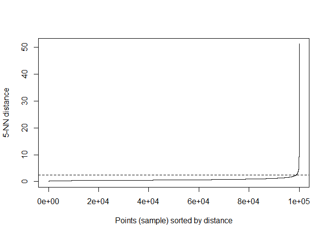

```r
#Set sample parameters for DBSCAN
n=20000
MinPts=round(log(n)) # a common approach to setting minimum number of points without domain knowledge

#create sample
set.seed(123)
samp<- sample(1:nrow(per_provider), n)

#set numeric calumn index
num_cols<-10:25

#scale and make sure data is a df
per_provider[,num_cols]<- scale(per_provider[,num_cols])
per_provider<-per_provider%>%as.data.frame()

#run PCA on data to identify which PC's to cluster on
perp_PCA <- prcomp(per_provider[samp,num_cols])

# find # of PC's to keep and select the top PC's for clustering that makes the total vatriance explained >90%
v<-summary(perp_PCA) #store summary values
i=0 # create step variable that will identify number of PC's
sum_var<-0 #create stoping variable
while(sum_var<.9){
  i=i+1
  sum_var<-sum(v$importance[2,1:i])
}

#reduce PC's
perp_PCA <-perp_PCA$x[,1:i]

#look at elbow to set eps parameter
dbscan::kNNdistplot(perp_PCA, k =  5)
abline(h = 2.5, lty = 2) #set eps to 2.5 which is aproximately at elbow
```

```r
eps<-2.5
```

I set my *MinPts* to log(n), *10*, where n is the number of observations, in this case 20,000. This is a common method to set this parameter without domain knowledge to guide this decision. I also limited my principle components (PC’s) to *6*, since that is the minimum number of PC’s where the explained variance is greater than 90%. The plot above shows the elbow where I set my *eps* parameter. The elbow apears to be at or around *2.5*.

```r
# model 1 - DBSCAN
set.seed(123)
per_provider_db <- fpc::dbscan(data = perp_PCA, eps = eps, MinPts = MinPts )

#view cluster assignment
  kable(table(per_provider_db$cluster),col.names  = c("Cluster", "Number Assigned"))
```

| Cluster | Number Assigned |
| --- | --- |
| 0 | 230 |
| 1 | 19770 |

The majority of observations have been identified into cluster 1 with about 1% in cluster 0.

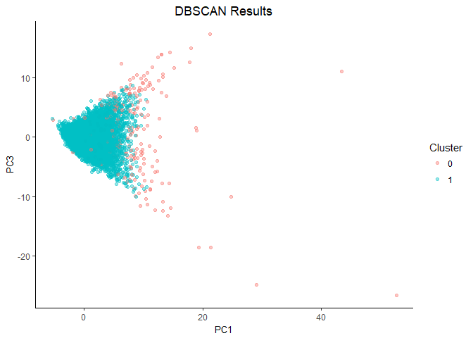

```r
#plot 1
ggplot(perp_PCA%>%as.data.frame(), aes(x=PC1, y=PC3,  col=as.factor(per_provider_db$cluster)))+
  geom_point(alpha=.4)+
  mytheme+
  labs(title="DBSCAN Results")+
  scale_color_discrete(name="Cluster")
```

This visual is very interesting as it shows most of the outliers to the extreme with few inside the majority, ot high density area of cluster 1.

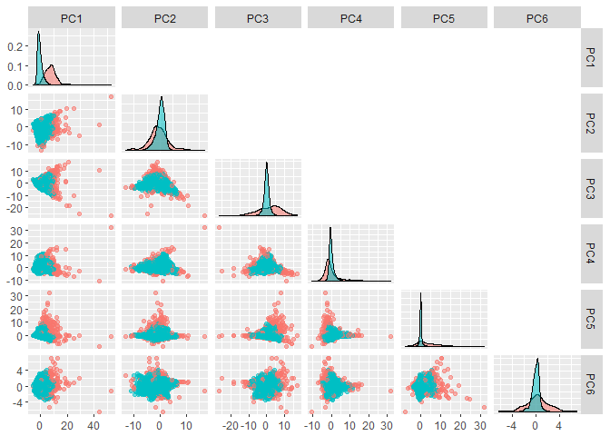

```r
#plot 3
ggpairs(perp_PCA%>%as.data.frame(),
        columns = colnames(perp_PCA),
         mapping=ggplot2::aes(colour = as.factor(per_provider_db$cluster), alpha=.8),
        lower=list(continuous='points'),
        upper=list(continuous='blank'))
```

The plot appears to have identified the two distributions pretty well as most scatter plots show cluster 0 on the outer boundaries of cluster 1. The distributions of both clusters are very different as well which makes me think this is a good clustering.

```r
# model 3 - Hierarchical DBSCAN
set.seed(1)
per_provider_hdb <- hdbscan(perp_PCA, minPts=MinPts)

table(per_provider_hdb$cluster)
```

```
##
##     0     1     2
## 12482    94  7424
```

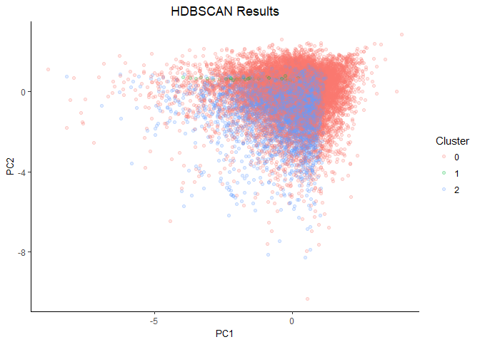

```r
ggplot(perp_PCA%>%as.data.frame()%>% mutate(cluster = as.factor(per_provider_hdb$cluster)), aes(x=PC1%>%abs()%>%log(), y=PC2%>%abs()%>%log(),col=cluster))+
  geom_point(alpha=.2)+
  mytheme+
  labs(title="HDBSCAN Results", x= "PC1", y="PC2")+
  scale_color_discrete(name="Cluster")
```

```r
#plot 4 - 3D plot
pca3d(perp_PCA%>%abs()%>%log(), group=as.factor(per_provider_hdb$cluster), show.ellipses=TRUE,
ellipse.ci=0.75, show.plane=FALSE)
```

```
## [1] 0.1769924 0.2062866 0.1720686
```

```r
snapshotPCA3d(file="HDBSCAN.png")
```

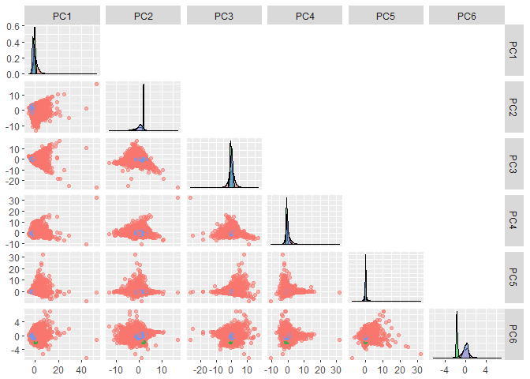

```r
#plot 5
ggpairs(perp_PCA%>%as.data.frame(),
        columns = colnames(perp_PCA),
         mapping=ggplot2::aes(colour = as.factor(per_provider_hdb$cluster), alpha=.8),
        lower=list(continuous='points'),
        upper=list(continuous='blank'))
```

The Hierarchical DBSCAN model is not as obviously useful. It appears that cluster 2 is a much denser area and has been clustered accordingly. However it is difficult to interpret the real reason why. I will keep model 1 for reporting outliers since the clusters are visualy different.

## Hidden Morkov Model (HMM)

The Hidden Markov Model is one that assumes there are unknown distributions of multiple samples mixed into observed output. These models are often refered to as mixture models. The goal of the HMM is to identify these separate distributions and categorize the outputs into their respective groups. The underlying assumption is that the characteristics of each sample are significantly different than the others.

```r
# Specify the model
hmm <- depmix(data = data.frame(perp_PCA),
              response = list(PC1 ~ 1, PC2 ~ 1, PC3 ~ 1, PC4 ~ 1, PC5 ~ 1, PC6 ~ 1),
              family = list(gaussian(), gaussian(), gaussian(), gaussian(), gaussian(), gaussian()),
              nstates = 2 )
# Fit the model by calling the "fit" function
hmmfit <- fit(hmm, verbose = FALSE)
```

```
## converged at iteration 33 with logLik: -184996.6
```

```r
hmmfit
```

```
## Convergence info: Log likelihood converged to within tol. (relative change)
## 'log Lik.' -184996.6 (df=27)
## AIC:  370047.2
## BIC:  370260.6
```

```r
# plot posterior state sequence for the 2-state model
post_probs <- posterior(hmmfit)
head(post_probs)
```

```
##   state        S1           S2
## 1     1 1.0000000 0.0000000000
## 2     1 0.9900917 0.0099082984
## 3     1 0.5543347 0.4456652658
## 4     1 0.9988837 0.0011162848
## 5     1 0.9881946 0.0118054036
## 6     1 0.9991130 0.0008869914
```

```r
sum(ifelse(post_probs$S1>.5,1,0))
```

```
## [1] 15581
```

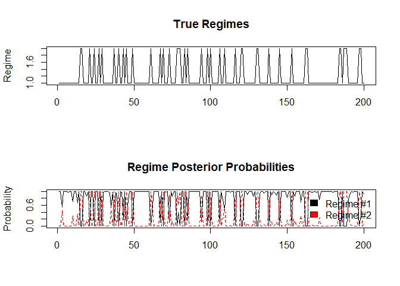

```r
#plot first 500 of HMM model
layout(matrix(c(1,2), 2, 1, byrow = TRUE))
# Plot the true regimes
matplot(post_probs$state[1:200], type='l', main='True Regimes',xlab='', ylab='Regime')
# Plot the probabilities of the regimes
matplot(post_probs[1:200,-1], type='l', main='Regime Posterior Probabilities', ylab='Probability')
legend(x='right', inset = 0,c('Regime #1','Regime #2'), fill=1:2, bty='n')
```

```r
report<- data.frame(per_provider[samp,],DBClust= per_provider_db$cluster, HDBClust= per_provider_hdb$cluster, HMM=ifelse(post_probs$S1>.5,1,0))

report<- report%>%arrange(Provider.Id, Provider.Name, DRG.Definition)

kable(head(report[,c(1:3,26:28)]))
```

| DRG.Definition | Provider.Id | Provider.Name | DBClust | HDBClust | HMM |
| --- | --- | --- | --- | --- | --- |
| 054 - NERVOUS SYSTEM NEOPLASMS W MCC | 10001 | SOUTHEAST ALABAMA MEDICAL CENTER | 1 | 2 | 1 |
| 070 - NONSPECIFIC CEREBROVASCULAR DISORDERS W MCC | 10001 | SOUTHEAST ALABAMA MEDICAL CENTER | 1 | 2 | 1 |
| 071 - NONSPECIFIC CEREBROVASCULAR DISORDERS W CC | 10001 | SOUTHEAST ALABAMA MEDICAL CENTER | 1 | 2 | 1 |
| 091 - OTHER DISORDERS OF NERVOUS SYSTEM W MCC | 10001 | SOUTHEAST ALABAMA MEDICAL CENTER | 1 | 2 | 1 |
| 177 - RESPIRATORY INFECTIONS & INFLAMMATIONS W MCC | 10001 | SOUTHEAST ALABAMA MEDICAL CENTER | 1 | 2 | 1 |
| 220 - CARDIAC VALVE & OTH MAJ CARDIOTHORACIC PROC W/O CARD CATH W CC | 10001 | SOUTHEAST ALABAMA MEDICAL CENTER | 1 | 2 | 1 |